#### Latest Version : 3.10.1 (Documenting @ Decmber-2021)

# 2.0 - Python version 3.* installation

### Windows Installation

- URL : https://www.python.org/downloads/
- Download latest version (3.10.1)
- Install downloaded installation file
- Open command prompt (winkey + cmd) and type `python --version` or `python -v` to check the version installed

### MacOS Installation

- URL : https://www.python.org/downloads/
- Download latest version (3.10.1)
- Install downloaded installation file
- Open terminal (cmd + space -> termincal -> enter) and type `python --version` or `python -v` to check the version installed

### Linux Installation

- Open Shell and execute the below commands
- sudo apt-get update
- sudo apt-get install python3.8 python3-pip
- Open shell/terminal and type `python --version` or `python -v` to check the version installed

## Step By Step Setup for Windows

### Step 1: Select Version of Python to Install

- URL : https://www.python.org/downloads/
- Download latest version (3.10.1)
- Install downloaded installation file

[figure not shown]

### Step 2: Verify Python Was Installed On Windows

- Navigate to the directory in which Python was installed on the system. In our case, it is `C:\Users\Username\AppData\Local\Programs\Python\Python*` since we have installed the latest version.
- Double-click `python.exe`.
- The output window show the version details like below image

[figure not shown]

### Step 3: Verify Pip Was Installed

- Open the Start menu and type "cmd."
- Select the Command Prompt application.
- Enter pip -V in the console.
  - If Pip was installed successfully, you should see the pip version details

[figure not shown]

  - If Pip has not been installed yet, then you see the following output:

    ```
     'pip' is not recognized as an internal or external command, Operable program or batch file.
    ```

### Step 4: Add Python Path to Environment Variables (Optional)

1. Open the Start menu and start the Run app.
2. Type sysdm.cpl and click OK. This opens the System Properties window.

[figure not shown]

3. Navigate to the Advanced tab and select Environment Variables.
4. Under System Variables, find and select the Path variable.
5. Click Edit.
6. Select the Variable value field. Add the path to the python.exe file preceded with a semicolon (;). For example, we have added ";C:\Users\Username\AppData\Local\Programs\Python\Python*"

[figure not shown]

7. Click OK and close all windows.

By setting this up, you can execute Python scripts like this: python script.py

Instead of this:C:\Users\Username\AppData\Local\Programs\Python\Python*\python script.py

As you can see, it is cleaner and more manageable.

### Step 5: Install virtualenv (Optional)

- You have Python, and you have Pip to manage packages. Now, you need one last software package - virtualenv. Virtualenv enables you to create isolated local virtual environments for your Python projects.

#### Why use virtualenv?

- Python software packages are installed system-wide by default. Consequently, whenever a single project-specific package is changed, it changes for all your Python projects. You would want to avoid this, and having separate virtual environments for each project is the easiest solution.

#### To install virtualenv:

1. Open the Start menu and type "cmd."
2. Select the Command Prompt application.
3. Type the following pip command in the console: `C:\Users\Username> pip install virtualenv`

# 2.1 - VS code (Visual Studio Code) installation & works

- Follow the instructions in url - https://code.visualstudio.com/docs/setup/windows

# 2.2 - Jupyter Notebook installation & works

- Official website for instllation - https://jupyter.org/install

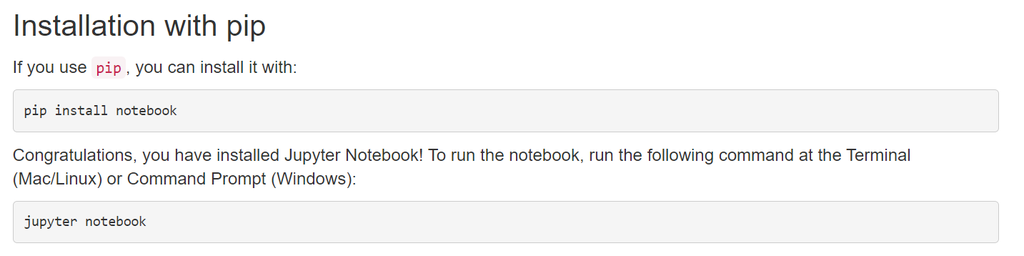

`Jupyter Notebook docs -` https://jupyter.readthedocs.io/en/latest/running.html#running